# Global Alcohol Consumption Patterns: Cross-Cultural Analysis

*By Mohammad Sayem Chowdhury*  
*Last Updated: June 13, 2025*

## Project Overview

This comprehensive analysis explores global alcohol consumption patterns across different countries and continents. Using statistical analysis and data visualization, I investigate cultural drinking habits, regional preferences, and consumption trends to understand how alcohol consumption varies worldwide.

**Author: Mohammad Sayem Chowdhury**  
**Project Type: Cross-Cultural Data Analysis**  
**Domain: Global Health & Social Analytics**  
**Dataset: World Health Organization Alcohol Consumption Data**

## Executive Summary

### Research Focus

This analysis examines global alcohol consumption patterns using comprehensive data on beer, wine, and spirit servings per capita across 193 countries. The goal is to uncover cultural drinking preferences, identify regional consumption trends, and develop insights into global alcohol consumption behaviors.

**Expected Impact**: Providing data-driven insights for public health policy, cultural studies, and international business strategies in the beverage industry.

You will need the following libraries:

```python
import pandas as pd
import numpy as np
import matplotlib.pyplot as plt
import matplotlib as mpl
```

**1.0 Importing the Data**

Load the csv:

```python
df= pd.read_csv('https://s3-api.us-geo.objectstorage.softlayer.net/cf-courses-data/CognitiveClass/DA0101EN/edx/project/drinks.csv')
```

```python
df.head()
```

|  | country | beer_servings | spirit_servings | wine_servings | total_litres_of_pure_alcohol | continent |
| --- | --- | --- | --- | --- | --- | --- |
| 0 | Afghanistan | 0 | 0 | 0 | 0.0 | Asia |
| 1 | Albania | 89 | 132 | 54 | 4.9 | Europe |
| 2 | Algeria | 25 | 0 | 14 | 0.7 | Africa |
| 3 | Andorra | 245 | 138 | 312 | 12.4 | Europe |
| 4 | Angola | 217 | 57 | 45 | 5.9 | Africa |

**Question 1**: Display the data types of each column using the attribute dtype.

```python
df.dtypes
```

```
country                          object
beer_servings                     int64
spirit_servings                   int64
wine_servings                     int64
total_litres_of_pure_alcohol    float64
continent                        object
dtype: object
```

**Question 2** use the method `groupby` to get the number of wine servings per continent:

```python
df_Wine = df[['continent','wine_servings']]
df_winegrp = df_Wine.groupby(['continent'], as_index=False).sum()
df_winegrp
```

|  | continent | wine_servings |
| --- | --- | --- |
| 0 | Africa | 862 |
| 1 | Asia | 399 |
| 2 | Europe | 6400 |
| 3 | North America | 564 |
| 4 | Oceania | 570 |
| 5 | South America | 749 |

**Question 3:** Perform a statistical summary and analysis of beer servings for each continent:

```python
df_beer = df[['continent','beer_servings']]
df_beergrp = df_beer.groupby(['continent'], as_index=True).describe()
df_beergrp
```

| continent | beer_servings count | beer_servings mean | beer_servings std | beer_servings min | beer_servings 25% | beer_servings 50% | beer_servings 75% | beer_servings max |
| --- | --- | --- | --- | --- | --- | --- | --- | --- |
| Africa | 53.0 | 61.471698 | 80.557816 | 0.0 | 15.00 | 32.0 | 76.00 | 376.0 |
| Asia | 44.0 | 37.045455 | 49.469725 | 0.0 | 4.25 | 17.5 | 60.50 | 247.0 |
| Europe | 45.0 | 193.777778 | 99.631569 | 0.0 | 127.00 | 219.0 | 270.00 | 361.0 |
| North America | 23.0 | 145.434783 | 79.621163 | 1.0 | 80.00 | 143.0 | 198.00 | 285.0 |
| Oceania | 16.0 | 89.687500 | 96.641412 | 0.0 | 21.00 | 52.5 | 125.75 | 306.0 |
| South America | 12.0 | 175.083333 | 65.242845 | 93.0 | 129.50 | 162.5 | 198.00 | 333.0 |

**Question 4:** Use the function boxplot in the seaborn library to produce a plot that can be used to show the number of beer servings on each continent.

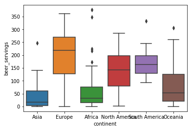

```python
import seaborn as sns
sns.boxplot(x="continent", y="beer_servings", data=df_beer)
plt.show()
```

**Question 5**: Use the function `regplot` in the seaborn library to determine if the number of wine servings is negatively or positively correlated with the number of beer servings.

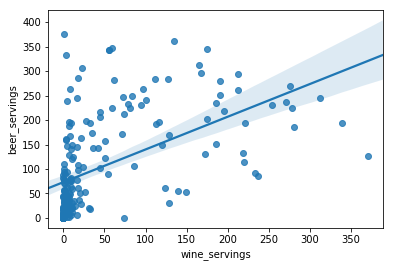

```python
import seaborn as sns
sns.regplot(x="wine_servings", y="beer_servings", data=df)
plt.show()
# Beer servings & Wine servings appear to be positively correlated.
# Also seems like there maybe some places where only Beer is served.
```

**Question 6:** Fit a linear regression model to predict the `'total_litres_of_pure_alcohol'` using the number of `'wine_servings'` then calculate $R^{2}$:

```python
from sklearn.linear_model import LinearRegression
lm = LinearRegression()
x = df[['wine_servings']]
y = df['total_litres_of_pure_alcohol']
lm.fit(x,y)
yhat = lm.predict(x)
print(yhat[0:5])
print("Intercept is ",lm.intercept_)
print("Slope is ",lm.coef_)
print("R^2 is ",lm.score(x,y))
```

```
[ 3.15407943  4.86088833  3.59658545 13.01564196  4.57642018]
Intercept is  3.1540794346874996
Slope is  [0.03160757]
R^2 is  0.4456875459787605
```

### Question 7

Use the list of features to predict the `'total_litres_of_pure_alcohol'`, split the data into training and testing and determine the $R^2$ on the test data, using the provided code:

```python
from sklearn.linear_model import LinearRegression
from sklearn.model_selection import train_test_split
x_data = df[['beer_servings','spirit_servings','wine_servings']]
y_data = df['total_litres_of_pure_alcohol']
x_train, x_test, y_train, y_test = train_test_split(x_data, y_data, test_size=0.4, random_state=0)
lr = LinearRegression()
lr.fit(x_train, y_train)
print("Train Data R^2:", lr.score(x_train, y_train))
print("Test Data R^2:", lr.score(x_test, y_test))
```

```
Train Data R^2: 0.9471204262013297
Test Data R^2: 0.7370737388267039
```

**Question 8 :** Create a pipeline object that scales the data, performs a polynomial transform and fits a linear regression model. Fit the object using the training data in the question above, then calculate the R^2 using. the test data. Take a screenshot of your code and the $R^{2}$. There are some hints in the notebook:

`'scale'`

`'polynomial'`

`'model'`

The second element in the tuple contains the model constructor

`StandardScaler()`

`PolynomialFeatures(include_bias=False)`

`LinearRegression()`

```python
from sklearn.pipeline import Pipeline
from sklearn.preprocessing import StandardScaler,PolynomialFeatures
from sklearn.linear_model import LinearRegression
from sklearn.model_selection import train_test_split

x_train, x_test, y_train, y_test = train_test_split(x_data, y_data, test_size=0.4, random_state=0)

input =[('scale',StandardScaler()),('polynomial',PolynomialFeatures(include_bias=False,degree=2)),('model',LinearRegression())]
pipe = Pipeline(input)
pipe.fit(x_train, y_train)
yhat = pipe.predict(x_data)
print("R^2 using Test data is", pipe.score(x_test, y_test))
print("R^2 using Training data is", pipe.score(x_train, y_train))
```

```
R^2 using Test data is 0.7594556586231647
R^2 using Training data is 0.9555197146227157
```

**Question 9**: Create and fit a Ridge regression object using the training data, setting the regularization parameter to 0.1 and calculate the $R^{2}$ using the test data. Take a screenshot of your code and the $R^{2}$

```python
from sklearn.linear_model import Ridge
from sklearn.linear_model import LinearRegression
from sklearn.model_selection import train_test_split

x_train, x_test, y_train, y_test = train_test_split(x_data, y_data, test_size=0.4, random_state=0)
RidgeModel = Ridge(alpha=0.1)
RidgeModel.fit(x_train, y_train)
yhat = RidgeModel.predict(x_test)
print("Test R^2:",RidgeModel.score(x_test, y_test))
print("Train R^2:",RidgeModel.score(x_train, y_train))
```

```
Test R^2: 0.7370737565866847
Train R^2: 0.9471204262013262
```

**Question 10** : Perform a 2nd order polynomial transform on both the training data and testing data. Create and fit a Ridge regression object using the training data, setting the regularization parameter to 0.1. Calculate the $R^{2}$ utilizing the test data provided. Take a screen-shot of your code and the $R^{2}$.

```python
pr = PolynomialFeatures(degree=2)
x_train_pr = pr.fit_transform(x_train)
x_test_pr = pr.fit_transform(x_test)
RidgeModel_pr = Ridge(alpha=0.1)
RidgeModel_pr.fit(x_train_pr, y_train)
print("RidgeModel Test data R^2: ",RidgeModel_pr.score(x_test_pr, y_test))
print("RidgeModel Train data R^2: ",RidgeModel_pr.score(x_train_pr, y_train))
```

```
RidgeModel Test data R^2:  0.7594556764530759
RidgeModel Train data R^2:  0.9555197146226246
```

**Sources**

[Dear Mona Followup: Where Do People Drink The Most Beer, Wine And Spirits?](https://fivethirtyeight.com/features/dear-mona-followup-where-do-people-drink-the-most-beer-wine-and-spirits/) by By Mona Chalabi , you can download the dataset [here](https://github.com/fivethirtyeight/data/tree/master/alcohol-consumption).